# Testing out Plotting capabilities in Rstudio

Spencer Pao

6/13/2021

# Markdown (You can also LaTex Format as a Package in Rmarkdown)

- You would typically output ONLY the visualizations with some customized text to illustrate what you are communicating. However, I will also be including the code that generates these graphics.

You can think of this setup as Jupyter Notebooks in Rstudio. We have chunks, which are blocks of code.

- You can run them individually and run like ordered objects.
- You can then output the code and visualizations to a PDF, HTML, or Word document if you so choose. I will be demonstrating how to do this at the end of the video.
- When you attempt to knit your document, make sure to not have any errors when you are running the document else you will have to re-knit everything once more.
- Lastly, when you are knitting your code, you will have to run the entire RMD file, and this can take particularly long. Thus, don’t attempt to knit your document if you have extremely long run times, especially if you are prone to error.

### These are the packages that I’ll be using to create such graphics.

```r
library(dplyr)
```

```r
library(ggplot2)
library(vote)
library(gganimate)
library(gapminder)
library(gifski)
library(maps)
#install.packages(transformr)
```

### Let’s load in our datasets that we will be visualizing today.

```r
data("airquality")
data(uspop)
```

### Adding an additional column to the airquality dataset to get Solar Radiation ‘bucket’

```r
m <- c("High Intensity","Medium Intensity","Low Intensity")

airquality <- airquality %>%
  mutate(
      Intensity = case_when(Solar.R < 100 ~ "Low Intensity",
                            Solar.R < 200 ~ "Medium Intensity",
                            TRUE ~ "High Intensity")
    ) %>%
  arrange(sapply(Intensity, function(x) which(x == m))) %>%
  mutate(
    group = factor(Intensity, levels = c("High Intensity",
                                         "Medium Intensity",
                                         "Low Intensity"))
  )
head(airquality)
```

```
##   Ozone Solar.R Wind Temp Month Day      Intensity          group
## 1    18     313 11.5   62     5   4 High Intensity High Intensity
## 2    NA      NA 14.3   56     5   5 High Intensity High Intensity
## 3    28      NA 14.9   66     5   6 High Intensity High Intensity
## 4    23     299  8.6   65     5   7 High Intensity High Intensity
## 5     7      NA  6.9   74     5  11 High Intensity High Intensity
## 6    16     256  9.7   69     5  12 High Intensity High Intensity
```

### Let’s checkout airquality (Temperature vs Ozone)

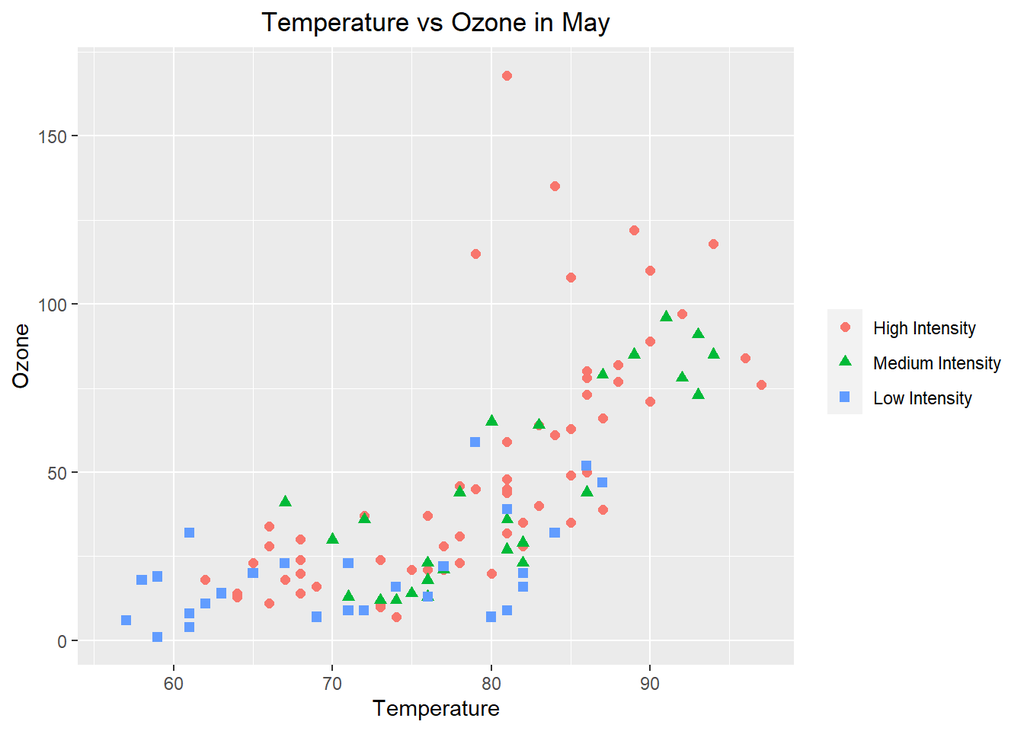

```r
ggplot(data = airquality, aes(x = Temp, y = Ozone, color = group)) +
  geom_point(aes(shape = group), size = 2) +
  xlab("Temperature") +
  ylab("Ozone") +
  ggtitle("Temperature vs Ozone in May") +
  theme(plot.title = element_text(hjust = 0.5), legend.title = element_blank())
```

### Maybe we want to annotate a specific section of the plot? Let’s get a rectangle somewhere…

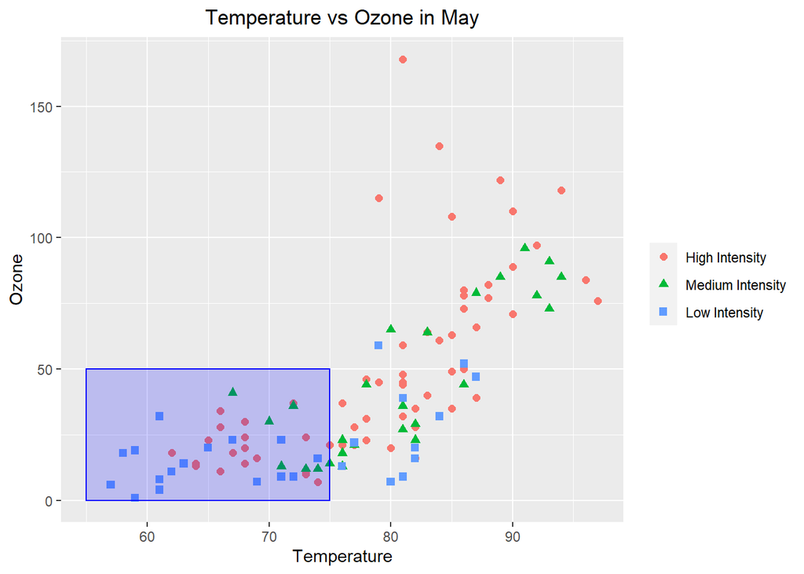

```r
ggplot(data = airquality, aes(x = Temp, y = Ozone, color = group)) +
  geom_point(aes(shape = group), size = 2) +
  xlab("Temperature") +
  ylab("Ozone") +
  ggtitle("Temperature vs Ozone in May") +
  theme(plot.title = element_text(hjust = 0.5), legend.title = element_blank()) +
  annotate("rect", xmin=c(55), xmax=c(75), ymin=c(0) , ymax=c(50), alpha=0.2, color="blue", fill="blue")
```

```r
# We can also include a segment i.e
#annotate("segment", x = 55, xend = 75, y = 0, yend = 100, colour = "purple", size=3, alpha=0.6)
```

### Getting Airquality data into a desireable group format.

```r
airquality_bc <- airquality %>%
  group_by(group) %>%
  summarise_all(list(mean), na.rm = TRUE)
airquality_bc
```

```
## # A tibble: 3 x 8
##   group            Ozone Solar.R  Wind  Temp Month   Day Intensity
##   <fct>            <dbl>   <dbl> <dbl> <dbl> <dbl> <dbl>     <dbl>
## 1 High Intensity    50.8   260.   9.95  79.2  6.94  15.3        NA
## 2 Medium Intensity  44.3   158.   8.86  80.6  7.24  14.9        NA
## 3 Low Intensity     19.9    53.4 11.2   71.9  6.85  18.1        NA
```

### High Quality Barchart

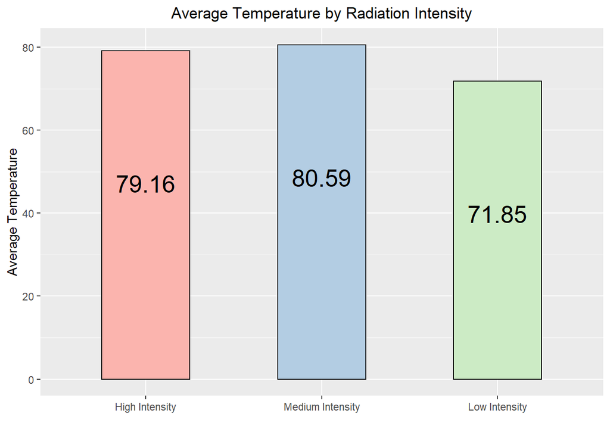

```r
ggplot(airquality_bc, aes(group, Temp)) +
  geom_bar(aes(fill=group),colour = "black",stat = "identity", width = 0.5) +
  scale_fill_brewer(palette="Pastel1") +
  xlab("") +
  ylab("Average Temperature") +
  ggtitle("Average Temperature by Radiation Intensity") +
  theme(plot.title = element_text(hjust = 0.5), legend.position = "none") +
  geom_text(
    aes(label = round(Temp,2)),
    colour = "black", size = 7,
    vjust = 8, position=position_stack(vjust=1)
    # + scale_fill_brewer(palette = "Pastel1") # I really like this color scheme!
  )
```

# Let’s get a Pie chart here.

```r
data(ims_election) # Loading in the data
ims_pie <- ims_election %>%
  summarise_all(list(sum), na.rm = TRUE)
ims_pie <- t(ims_pie) # Transpose the data
colnames(ims_pie)[1] <- "Counts"
ims_pie <- as.data.frame(ims_pie)
ims_pie <- tibble::rownames_to_column(ims_pie, "Person")
ims_pie <- ims_pie %>%
  mutate(proportion = Counts / sum(Counts) * 100) %>%
  mutate(yposition= cumsum(proportion) - 0.5 * proportion)
ims_pie
```

```
##     Person Counts proportion yposition
## 1  Tilmann   1141   9.045505  4.522752
## 2    Julie   1180   9.354685 13.722848
## 3   Jasper   1276  10.115744 23.458062
## 4       Li   1281  10.155383 33.593626
## 5     Wang   1241   9.838275 43.590455
## 6  Hillary   1307  10.361503 53.690344
## 7   Claire   1318  10.448708 64.095450
## 8    Oscar   1340  10.623117 74.631362
## 9   Declan   1248   9.893769 84.889805
## 10  Roisin   1282  10.163311 94.918345
```

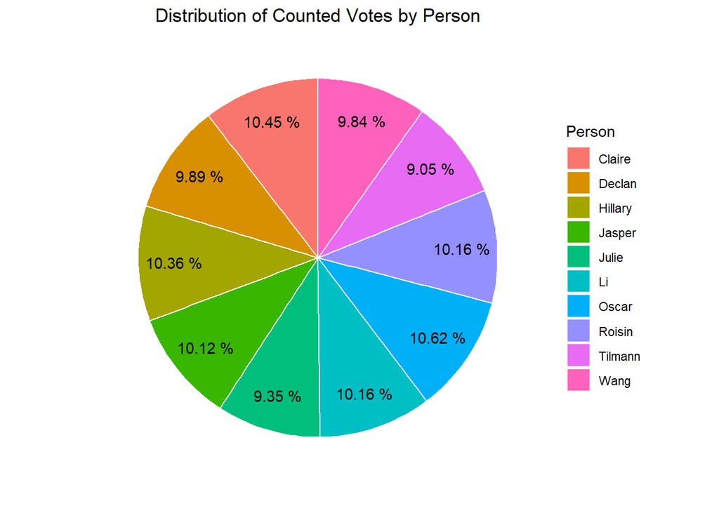

```r
ggplot(ims_pie, aes(x="", y=Counts, fill=Person)) +
  geom_bar(stat="identity", width=1, color="white") +
  coord_polar("y", start=0) +
  geom_text(aes(label = paste(round(proportion, 2), "%"), x = 1.3),
            position = position_stack(vjust = 0.5)) +
  theme_classic() +
  theme(plot.title = element_text(hjust=0.5),
        axis.line = element_blank(),
        axis.text = element_blank(),
        axis.ticks = element_blank()) +
  ggtitle("Distribution of Counted Votes by Person") +
  xlab("") +
  ylab("") +
  coord_polar("y")
```

### Now, Let’s get into the more advanced graphics. Interested in getting a moving graphic?

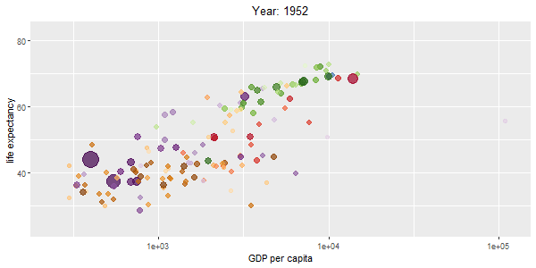

```r
## standard ggplot2
myPlot <- ggplot(data = gapminder, aes(gdpPercap, lifeExp, size = pop, colour = country)) +
  geom_point(alpha = 0.7, show.legend = FALSE) + # alpha controls transparancy
  scale_colour_manual(values = country_colors) +
  scale_size(range = c(2, 12)) +
  scale_x_log10() +
  # Here comes the gganimate specific bits
  labs(title = 'Year: {frame_time}', x = 'GDP per capita', y = 'life expectancy') +
  transition_time(year) +
  ease_aes('linear') +
  theme(plot.title = element_text(hjust = 0.5))

animate(myPlot, duration = 5, fps = 30, width = 600, height = 300, renderer = gifski_renderer())
anim_save("output.gif") # Save as gif so that when we do RMD, it can search for the output and overlay on html document.
```

Data Citation: MIT Election Data and Science Lab, 2017, “U.S. President 1976–2020”, https://doi.org/10.7910/DVN/42MVDX, Harvard Dataverse, V6, UNF:6:4KoNz9KgTkXy0ZBxJ9ZkOw== [fileUNF]

### Getting the most candidate votes from each state.

```r
voting <- read.csv("voting_data_1976_2020.csv")
v <- voting %>%
  group_by(year, state) %>%
  slice(which.max(candidatevotes)) %>%
  filter(year == 1980) %>%
  as.data.frame()

head(v)
```

```
##   year      state state_po state_fips state_cen state_ic       office
## 1 1980    ALABAMA       AL          1        63       41 US PRESIDENT
## 2 1980     ALASKA       AK          2        94       81 US PRESIDENT
## 3 1980    ARIZONA       AZ          4        86       61 US PRESIDENT
## 4 1980   ARKANSAS       AR          5        71       42 US PRESIDENT
## 5 1980 CALIFORNIA       CA          6        93       71 US PRESIDENT
## 6 1980   COLORADO       CO          8        84       62 US PRESIDENT
##        candidate party_detailed writein candidatevotes totalvotes  version
## 1 REAGAN, RONALD     REPUBLICAN   FALSE         654192    1341929 20210113
## 2 REAGAN, RONALD     REPUBLICAN   FALSE          86112     158445 20210113
## 3 REAGAN, RONALD     REPUBLICAN   FALSE         529688     873945 20210113
## 4 REAGAN, RONALD     REPUBLICAN   FALSE         403164     837582 20210113
## 5 REAGAN, RONALD     REPUBLICAN   FALSE        4522994    8582938 20210113
## 6 REAGAN, RONALD     REPUBLICAN   FALSE         652264    1184450 20210113
##   notes party_simplified
## 1    NA       REPUBLICAN
## 2    NA       REPUBLICAN
## 3    NA       REPUBLICAN
## 4    NA       REPUBLICAN
## 5    NA       REPUBLICAN
## 6    NA       REPUBLICAN
```

```r
centroid_coordinates <- read.csv("centroid_coordinates.csv")
head(centroid_coordinates)
```

```
##   state_po Latitude  Longitude           S       state
## 1       AL 32.31823  -86.90230     Alabama     alabama
## 2       AR 35.20105  -91.83183    Arkansas    arkansas
## 3       AZ 34.04893 -111.09373     Arizona     arizona
## 4       CA 36.77826 -119.41793  California  california
## 5       CO 39.55005 -105.78207    Colorado    colorado
## 6       CT 41.60322  -73.08775 Connecticut connecticut
```

```r
# Want to make sure that everything can join...
v$state <- tolower(v$state)

us_states <- map_data("state")
colnames(us_states)[5] <- "state"
head(us_states)
```

```
##        long      lat group order   state subregion
## 1 -87.46201 30.38968     1     1 alabama      <NA>
## 2 -87.48493 30.37249     1     2 alabama      <NA>
## 3 -87.52503 30.37249     1     3 alabama      <NA>
## 4 -87.53076 30.33239     1     4 alabama      <NA>
## 5 -87.57087 30.32665     1     5 alabama      <NA>
## 6 -87.58806 30.32665     1     6 alabama      <NA>
```

```r
# Left Join on voting data and us_states
v_plot <- left_join(us_states, v)
head(v_plot)
```

```
##        long      lat group order   state subregion year state_po state_fips
## 1 -87.46201 30.38968     1     1 alabama      <NA> 1980       AL          1
## 2 -87.48493 30.37249     1     2 alabama      <NA> 1980       AL          1
## 3 -87.52503 30.37249     1     3 alabama      <NA> 1980       AL          1
## 4 -87.53076 30.33239     1     4 alabama      <NA> 1980       AL          1
## 5 -87.57087 30.32665     1     5 alabama      <NA> 1980       AL          1
## 6 -87.58806 30.32665     1     6 alabama      <NA> 1980       AL          1
##   state_cen state_ic       office      candidate party_detailed writein
## 1        63       41 US PRESIDENT REAGAN, RONALD     REPUBLICAN   FALSE
## 2        63       41 US PRESIDENT REAGAN, RONALD     REPUBLICAN   FALSE
## 3        63       41 US PRESIDENT REAGAN, RONALD     REPUBLICAN   FALSE
## 4        63       41 US PRESIDENT REAGAN, RONALD     REPUBLICAN   FALSE
## 5        63       41 US PRESIDENT REAGAN, RONALD     REPUBLICAN   FALSE
## 6        63       41 US PRESIDENT REAGAN, RONALD     REPUBLICAN   FALSE
##   candidatevotes totalvotes  version notes party_simplified
## 1         654192    1341929 20210113    NA       REPUBLICAN
## 2         654192    1341929 20210113    NA       REPUBLICAN
## 3         654192    1341929 20210113    NA       REPUBLICAN
## 4         654192    1341929 20210113    NA       REPUBLICAN
## 5         654192    1341929 20210113    NA       REPUBLICAN
## 6         654192    1341929 20210113    NA       REPUBLICAN
```

```r
# Get the abbreviation with the centroids...
centroid_coordiantes <- left_join(centroid_coordinates, v)
```

### Now, we have plotting capabailities on the US maps.

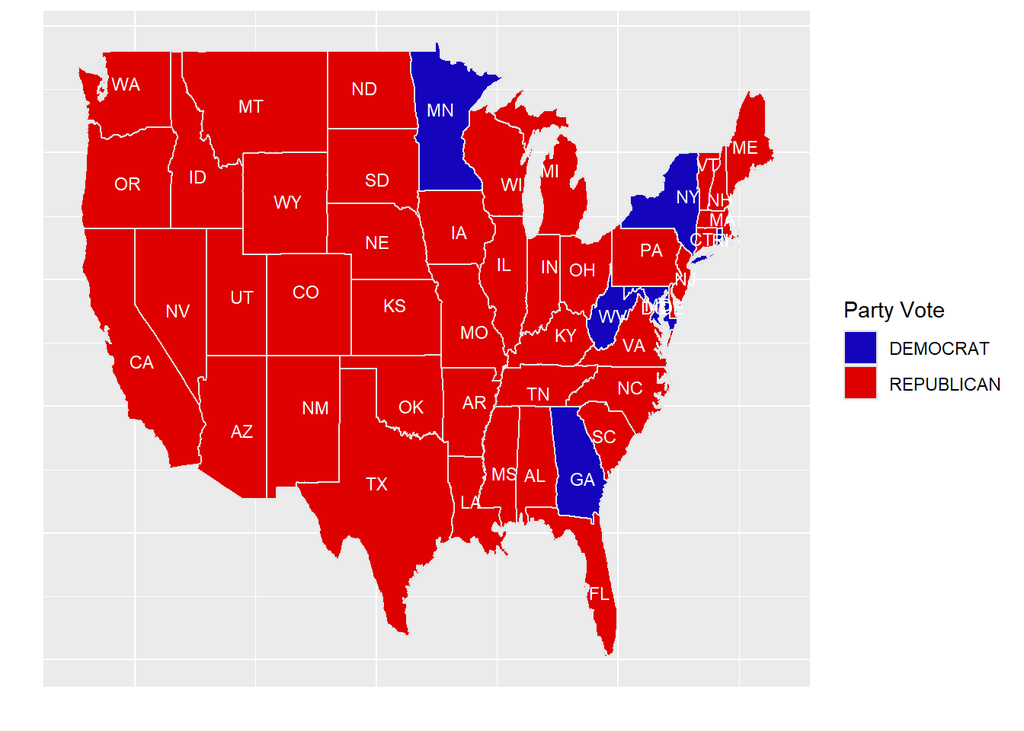

```r
party_colors <- c("#1405BD", "#DE0100")  # Democrat and Republican
state_label <- v_plot %>%
                group_by(state_po) %>%
                select(long,lat) %>%
                summarise_all(mean)
colnames(state_label) <- c("state_abbrev", "Longitude", "Latitude")


ggplot(data = v_plot,
       mapping = aes(x = long,
                     y = lat,
                     group = group,
                     fill = party_simplified)) +
  geom_polygon(color = "gray90", size = 0.5) +
  with(centroid_coordiantes,
       annotate(geom="text",
                x = Longitude,
                y=Latitude,
                label = state_po,
                size = 3,
                colour = 'white')) +
  scale_fill_manual(values=c("#1405BD",
                             "#DE0100"))+
  xlab("") +
  ylab("") +
  theme(axis.ticks = element_blank()) +
  theme(axis.text = element_blank()) +
  guides(fill=guide_legend(title="Party Vote"))
```

### Let’s see the plots in animation now! :)

```r
# Re-cleaning the data to get all years
v <- voting %>%
  group_by(year, state) %>%
  slice(which.max(candidatevotes)) %>%
  #filter(year == 1976) %>%
  as.data.frame()
v$state <- tolower(v$state)

# But, to make the animation smooth, we need to have 'consecutive' years. Since
# US elections only happen once every 4 years, I will go ahead and duplicate each row
# an additional 3 times and increment the year by 1.
v1 <- v
v1$year = v1$year + 1
v2 <- v
v2$year = v2$year + 2
v3 <- v
v3$year = v3$year + 3

# Combine everything...
v <- rbind(v,v1,v2,v3)


# Left Join on voting data and us_states
v_plot <- left_join(us_states, v)
head(v_plot)
```

```
##        long      lat group order   state subregion year state_po state_fips
## 1 -87.46201 30.38968     1     1 alabama      <NA> 1976       AL          1
## 2 -87.46201 30.38968     1     1 alabama      <NA> 1980       AL          1
## 3 -87.46201 30.38968     1     1 alabama      <NA> 1984       AL          1
## 4 -87.46201 30.38968     1     1 alabama      <NA> 1988       AL          1
## 5 -87.46201 30.38968     1     1 alabama      <NA> 1992       AL          1
## 6 -87.46201 30.38968     1     1 alabama      <NA> 1996       AL          1
##   state_cen state_ic       office         candidate party_detailed writein
## 1        63       41 US PRESIDENT     CARTER, JIMMY       DEMOCRAT   FALSE
## 2        63       41 US PRESIDENT    REAGAN, RONALD     REPUBLICAN   FALSE
## 3        63       41 US PRESIDENT    REAGAN, RONALD     REPUBLICAN   FALSE
## 4        63       41 US PRESIDENT BUSH, GEORGE H.W.     REPUBLICAN   FALSE
## 5        63       41 US PRESIDENT BUSH, GEORGE H.W.     REPUBLICAN   FALSE
## 6        63       41 US PRESIDENT      DOLE, ROBERT     REPUBLICAN   FALSE
##   candidatevotes totalvotes  version notes party_simplified
## 1         659170    1182850 20210113    NA         DEMOCRAT
## 2         654192    1341929 20210113    NA       REPUBLICAN
## 3         872849    1441713 20210113    NA       REPUBLICAN
## 4         815576    1378476 20210113    NA       REPUBLICAN
## 5         804283    1688060 20210113    NA       REPUBLICAN
## 6         769044    1534349 20210113    NA       REPUBLICAN
```

```r
# Get the abbreviation with the centroids...
centroid_coordiantes <- left_join(centroid_coordinates, v)
```

### Plotting the animation…

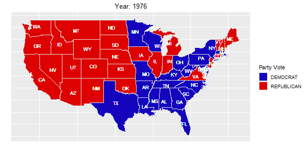

```r
map_plot <- ggplot(data = v_plot,
                   aes(x = long,
                       y = lat,
                       group = group,
                       fill = party_simplified)) +
  geom_polygon(color = "gray90", size = 0.5) +
  with(centroid_coordiantes, annotate(geom="text",
                                      x = Longitude,
                                      y=Latitude,
                                      label = state_po,
                                      size = 3,
                                      colour = 'white')) +
  scale_fill_manual(values=c("#1405BD", "#DE0100"))+
  xlab("") +
  ylab("") +
  theme(axis.ticks = element_blank()) +
  theme(axis.text = element_blank()) +
  guides(fill=guide_legend(title="Party Vote")) +
  # Here comes the gganimate specific bits
  labs(title = 'Year: {frame_time}') +
  transition_time(year) +
  theme(plot.title = element_text(hjust = 0.5))

animate(map_plot, duration = 5, fps = 30, width = 600, height = 300, renderer = gifski_renderer())
anim_save("map.gif")
```